# Cyclistic Bike-Share Case Study

Krithik vasan S

2026-03-24

## Business Task

Cyclistic is a bike-share company aiming to increase profitability by converting casual riders into annual members. As a data analyst, the objective of this analysis is to understand how casual riders and members use the service differently and provide actionable recommendations.

## Data Source

The dataset used for this analysis consists of trip data from Q1 2020. It includes ride timestamps, station names, and user type (member vs casual).

Provided by Cyclistic Bikeshare CO. through Coursera for the Capstone project

## Data Cleaning & Preparation

The dataset was preprocessed to ensure consistency and reliability for analysis.

- Date and time columns were converted from character format to datetime format to enable time-based calculations.
- Additional variables were created to support analysis, including ride length (in minutes) and day of the week.
- Further cleaning steps were performed to improve data quality. Records with missing user type information were removed, as they could not be categorized into casual or member segments.
- Additionally, rides with durations less than one minute or exceeding 24 hours were excluded, as these values likely represent data entry errors or system anomalies.

These steps ensured that the dataset reflects realistic user behavior patterns and is suitable for analysis.

## Analysis & Visualizations

The following analysis explores behavioral differences between casual riders and annual members using Q1 2020 data.

### 1. Ride Frequency by Day of Week

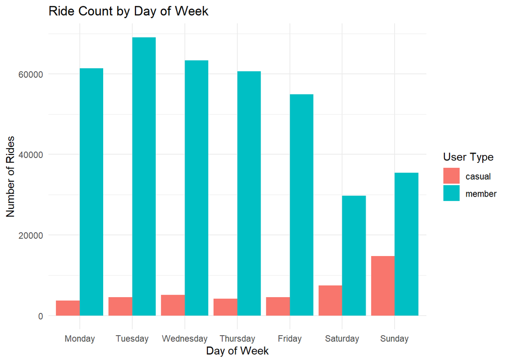

Members exhibit higher ride frequency during weekdays, indicating commuting behavior, while casual riders show increased activity on weekends, suggesting leisure-oriented usage.

### 2. Average Ride Length

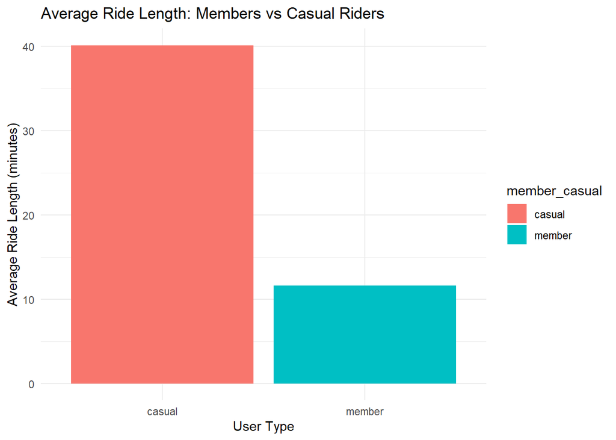

Casual riders tend to take longer rides compared to members, indicating more recreational usage, whereas members use the service for shorter, more frequent trips.

### 3. Ride Patterns by Hour

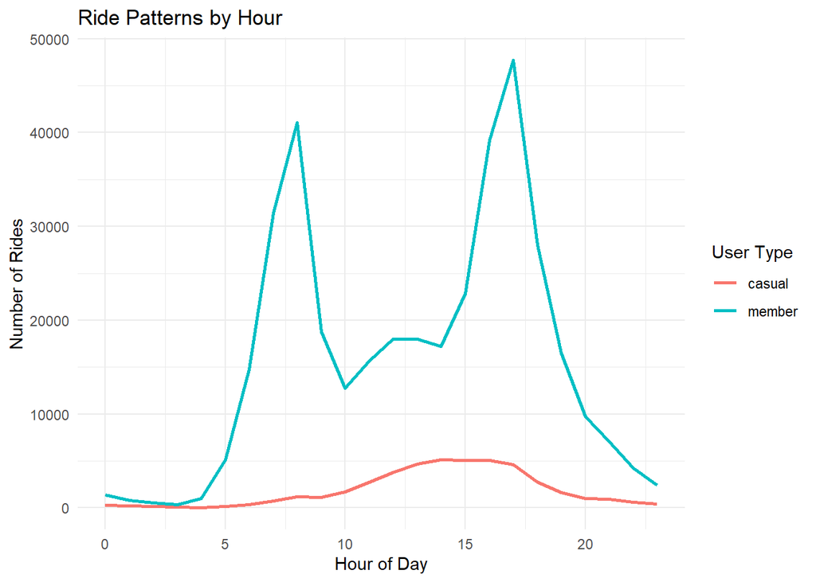

Members show peak usage during typical commuting hours, while casual riders display more evenly distributed usage throughout the day, with slight increases during afternoon hours.

### 4. Top Start Stations

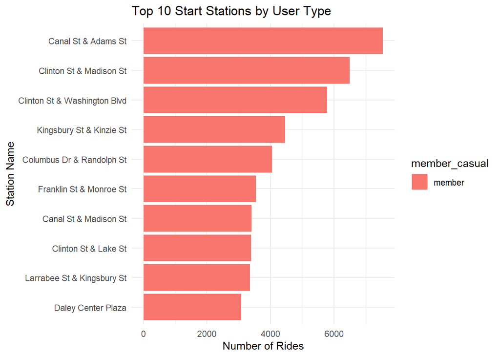

## Conclusion

The analysis highlights clear behavioral differences between casual riders and annual members. Casual riders exhibit patterns consistent with leisure usage, while members primarily use the service for commuting. By targeting casual riders with tailored marketing strategies and incentives, Cyclistic can increase annual memberships and drive higher profitability.